# Code style

Jae Yeon Kim

07 November, 2022

# 1 Code style

## 1.1 Write readable code

- Naming matters
  - When naming files, remember the following three rules:
    - Machine-readable (avoid spaces, punctuation, periods, and any other special characters except _ and -)
    - Human readable (should be meaningful. No text1, image1, etc.)
    - Ordering (e.g., 01, 02, 03, … )

```r
# Good
fit_models.R

# Bad
fit models.R
```

- When naming objects:
  - Don’t use special characters.
  - Don’t capitalize.

```r
# Good
day_one

# Bad
DayOne
```

- When naming functions:
  - Don’t use special characters.
  - Don’t capitalize.
  - Use `verbs` instead of `nouns.` (Functions do something!)

```r
# Good
run_rdd

# Bad
rdd
```

- Spacing

Some people do spacing by pressing the Tab key, and others do it by pressing the Space key multiple times (and this is a serious subject).

[video not shown]

Tabs versus Spaces

```r
# Good
x[, 1]

mean(x, na.rm = TRUE)

# Bad
x[,1]

mean (x, na.rm = TRUE)
```

- Indenting

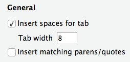

Roger Peng’s tweet

```r
# Good
if (y < 0) {
  message("y is negative")
}

# Bad
if (y < 0) {
message("Y is negative")}
```

- Long lines

```r
# Good
do_something_very_complicated(
  something = "that",
  requires = many,
  arguments = "some of which may be long"
)

# Bad
do_something_very_complicated("that", requires = many, arguments =
                              "some of which may be long"
                              )
```

- Comments
  - Use comments to explain your decisions.
  - But, show your code; Do not try to explain your code by comments.
  - Also, try to comment out rather than delete the code you experiment with.

```r
# Average sleep hours of Jae
jae %>%
  # By week
  group_by(week) %>%
  # Mean sleep hours
  summarise(week_sleep = mean(sleep, na.rm = TRUE))
```

- Pipes (chaining commands)

What is pipe (%) operator?

pipe operator is not from base R but from the **magrittr** package.

```r
if (!require(magrittr)) install.packages("magrittr")
```

```r
# Without using piper operator; lots of intermediary steps
office <- walk(home)
paper <- work(office)

# The intermediary steps are gone
papaer <- home %>%
    walk() %>%
    work()
```

```r
# Good
iris %>%
  group_by(Species) %>%
  summarize_if(is.numeric, mean) %>%
  ungroup() %>%
  gather(measure, value, -Species) %>%
  arrange(value)

# Bad
iris %>% group_by(Species) %>% summarize_all(mean) %>%
ungroup %>% gather(measure, value, -Species) %>%
arrange(value)
```

## 1.2 Write reusable code

- Pasting

> Copy-and-paste programming, sometimes referred to as just pasting, is the production of highly repetitive computer programming code, as produced by copy and paste operations. It is primarily a pejorative term; those who use the term are often implying a lack of programming competence. It may also be the result of technology limitations (e.g., an insufficiently expressive development environment) as subroutines or libraries would normally be used instead. However, there are occasions when copy-and-paste programming is considered acceptable or necessary, such as for boilerplate, loop unrolling (when not supported automatically by the compiler), or certain programming idioms, and it is supported by some source code editors in the form of snippets. - [Wikipedia](https://en.wikipedia.org/wiki/Copy-and-paste_programming) - It’s okay for pasting for the first attempt to solve a problem. But if you copy and paste three times (a.k.a. Rule of Three in programming), something’s wrong. You’re working too hard. You better need to be lazy. How can you do that?
- The following exercise was inspired by [Wickham’s example](http://adv-r.had.co.nz/Functional-programming.html).
- Let’s imagine `df` is a survey dataset.
  - `a, b, c, d` = Survey questions
  - `-99`: non-responses
  - Your goal: replace `-99` with `NA`

```r
# Data

set.seed(1234) # for reproducibility

df <- data.frame("a" = sample(c(-99, 1:3), size = 5 , replace= TRUE),
             "b" = sample(c(-99, 1:3), size = 5 , replace= TRUE),
             "c" = sample(c(-99, 1:3), size = 5 , replace= TRUE),
             "d" = sample(c(-99, 1:3), size = 5 , replace= TRUE))
```

```r
# Copy and paste
df$a[df$a == -99] <- NA
df$b[df$b == -99] <- NA
df$c[df$c == -99] <- NA
df$d[df$d == -99] <- NA
```

- Using a function
  - function: input + computation + output
  - If you write a function, you gain efficiency because you don’t need to copy and paste the computation part.

```r
# Create a custom function
fix_missing <- function(x) { # INPUT
  x[x == -99] <- NA # COMPUTATION
  x # OUTPUT
}

# Apply the function to each column (vector)
# This iterated part can and should be automated.
df$a <- fix_missing(df$a)
df$b <- fix_missing(df$b)
df$c <- fix_missing(df$c)
df$d <- fix_missing(df$d)

df
```

- Automation
  - Many options for automation in R: `for loop`, `apply` family, etc.
  - Here’s a tidy solution that comes from the `purrr` package.
  - The power and joy of one-liner.

```r
df <- purrr::map_df(df, fix_missing) # What is this magic? We will unpack the blackbox (`map_df()`) later.

df
```

- Takeaways
1. Your code becomes more reusable when it would be easier to **change, debug, and scale-up**. Don’t repeat yourself and embrace the power of lazy programming.

> Lazy, because only lazy programmers will want to write the kind of tools that might replace them in the end. Lazy, because only a lazy programmer will avoid writing monotonous, repetitive code—thus avoiding redundancy, the enemy of software maintenance and flexible refactoring. Mostly, the tools and processes that come out of this endeavor fired by laziness will speed up the production. - [Philipp Lenssen](http://blogoscoped.com/archive/2005-08-24-n14.html)
2. Only when your code becomes **reusable** you would become **efficient** in your data work. Otherwise, you need to start from scratch or copy and paste, when you work on a new project.

> Code reuse aims to save time and resources and reduce redundancy by taking advantage of assets that have already been created in some form within the software product development process.[2] The key idea in reuse is that parts of a computer program written at one time can be or should be used in the construction of other programs written at a later time. - Wikipedia